# SARS

## **Measuring growth rate and reproduction number for SARS-CoV-2 variants:**

[SARS GitHub Repository](https://github.com/daisyjeans2/SARS)

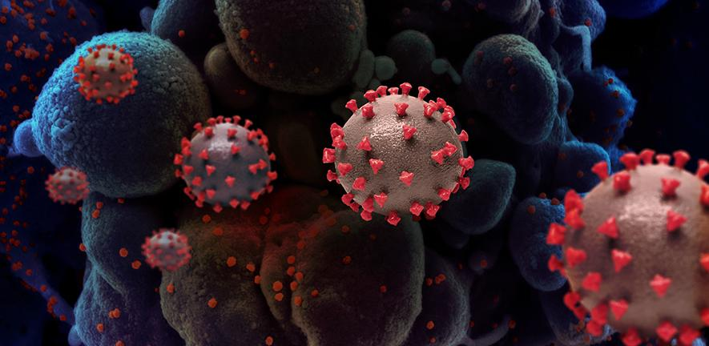

A coronavirus, the pathogenic agent of SARS-CoV-2

### Question 1:

#### 1) Download the dataset: download Genomes_per_week_in_England.csv from Canvas. This includes weekly counts of virus samples per lineage over time across England collected as part of Sanger Institute COG-UK.

```r
#reading in the raw genomes data

genomes_raw <- read.csv(here("Data", "Genomes_per_week_in_England.csv"))
```

```r
genomes_raw$date <- as.Date(genomes_raw$date) #correctly organising the date format
```

#### 2) Classify major lineages: identify the following variants as major lineages: B.1.1.7 (Alpha), B.1.617.2 (Delta), BA.1, BA.2, BA.2.75, BA.4, BA.5, BA.5.3 (BQ.1), and XBB. Group all other lineages into a single category labelled as Other.

```r
# Giving a name to each of the "major" lineages

major_lineages <- c(
  "B.1.1.7" = "Alpha",
  "B.1.617.2" = "Delta",
  "BA.1" = "BA.1",
  "BA.2" = "BA.2",
  "BA.2.75" = "BA.2.75",
  "BA.4" = "BA.4",
  "BA.5" = "BA.5",
  "BA.5.3" = "BQ.1",
  "XBB" = "XBB"
)

# Adding a "major lineages" column to the table; assigning the rest "Other"
genomes_raw <- genomes_raw %>%
  mutate(
    major_lineages = case_when(
      lineage %in% names(major_lineages) ~ major_lineages[lineage],  # Assign variant name
      TRUE ~ "Other"  # Group all others as "Other"
    )
  )
```

#### 3) Visualise the data: generate a stacked area plot showing the total counts of each major lineage over time.

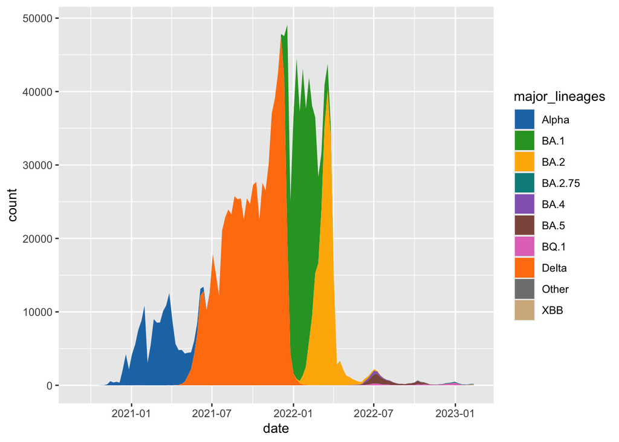

#### 3b) Generate another stacked area plot showing the frequencies (proportions) of each major lineage over time.

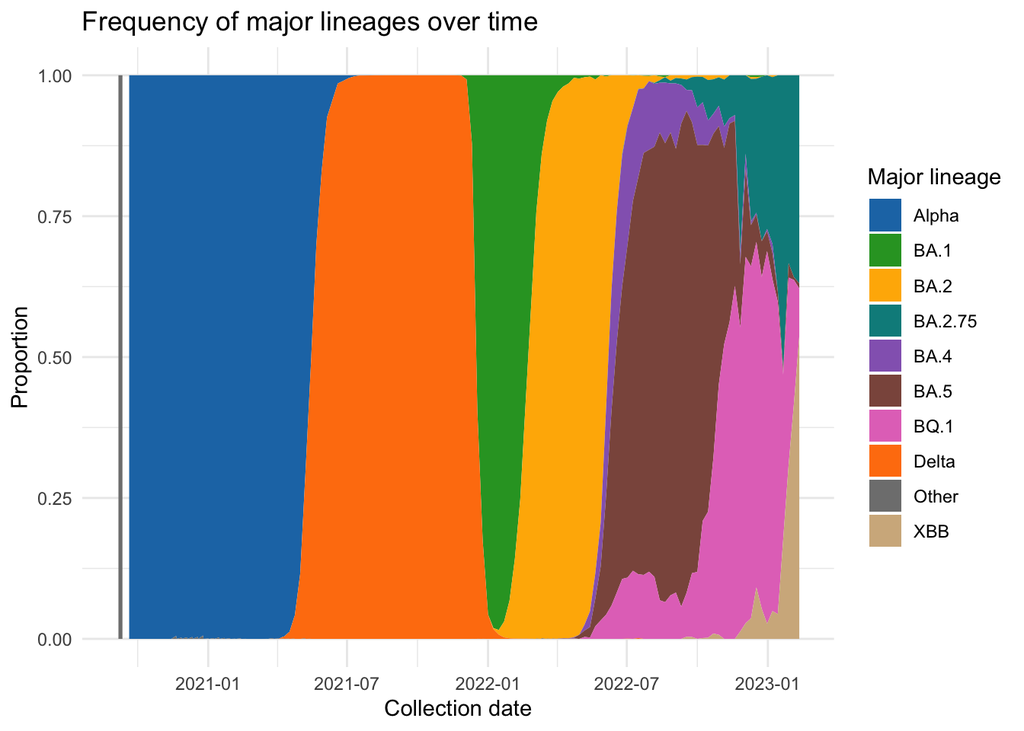

### Question 2:

#### 1) Visualise the COG-UK and ONS-CIS data for BA.2: plot the frequency trajectory for the BA.2 variant using both the Sanger dataset (weekly counts) and the ONS-CIS dataset (10-day bin counts from the practical).

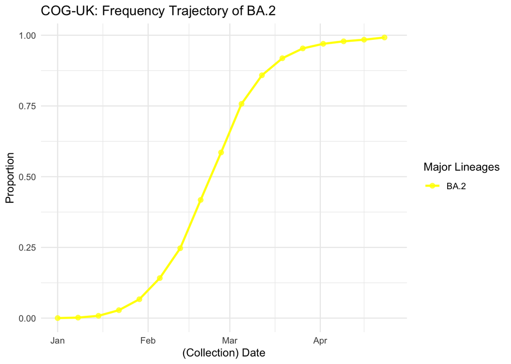

```r
#Visualising BA.2 frequency across time (amber colourscheme maintained for consistency)

BA.2$date <- as.Date(BA.2$date, format = "%m-%d-%y")

ggplot(BA.2, aes(x = date, y = lineage_frequency, color = major_lineages, group = major_lineages)) +
  geom_line(linewidth = 1) +
  geom_point(size = 2, alpha = 0.75) +
  scale_color_manual(
    values = c("BA.2" = "yellow"),
    labels = c("BA.2")
  ) +
  scale_x_date(
    limits = as.Date(c("2022-01-01", "2022-04-25")),
  ) +
  labs(
    title = "COG-UK: Frequency Trajectory of BA.2",
    x = "(Collection) Date",
    y = "Proportion",
    color = "Major Lineages"
  ) +
  theme_minimal()
```

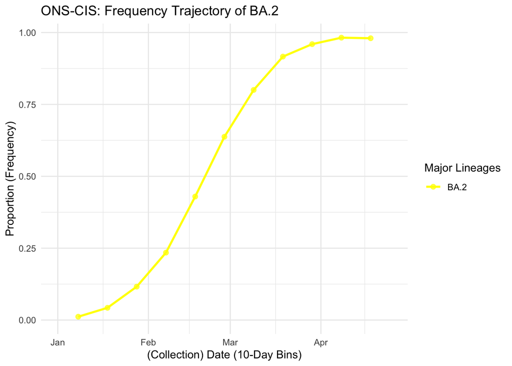

```r
# Visualising the ONS binned data using ggplot

ggplot(ONS_binned_BA.2, aes(x = date_bin, y = frequency, color = major_lineages, group = major_lineages)) +
  geom_line(linewidth = 1) +
  geom_point(size = 2, alpha = 0.75) +
  scale_color_manual(
    values = c("BA.2" = "yellow"), #again, amber colourscheme maintained for consistency
    labels = c("BA.2")
  ) +
  scale_x_date(
    limits = as.Date(c("2022-01-01", "2022-04-25")),
  ) +
  labs(
    title = "ONS-CIS: Frequency Trajectory of BA.2",
    x = "(Collection) Date (10-Day Bins)",
    y = "Proportion (Frequency)",
    color = "Major Lineages"
  ) +
  theme_minimal()
```

#### 2) Analysis: compare the two trajectories.

*Is there a difference in the timing of BA.2’s rise and when it reaches fixation?*

In the COVID-19 Genomics UK Consortium (COG-UK) dataset, it appears that BA.2 begins to rise in mid-January. Whereas, the Office for National Statistics COVID-19 Infection Survey (ONS-CIS) dataset shows BA.2 beginning to rise slightly earlier on, in early January.

In the COG-UK dataset, BA.2 appears to reach fixation in late April. However, in the ONS-CIS dataset, BA.2 also appears to reach fixation earlier, in early April.

*Reflect on potential reasons for these differences (sampling strategies and geographical or temporal biases in data collection)?*

Both projects occurred over the scope of three years, from 2020 to 2023. Clearly, BA.2 emerged in January 2022, which is within the temporal scope of both projects to be running efficiently. However, since it appears that BA.2 both rises, and reaches fixation earlier in the ONS-CIS dataset, that this dataset is potentially more sensitive to the early reception of data, which may be being overlooked in the COG-UK approach. We can explain this in the following manner:

Firstly, the COG-UK data is opportunistically, as opposed to systematically sampled (as in the case for the ONS-CIS) - this makes it uneven. In terms of the COG-UK data, the samples are derived from Lighthouse Labs, covering most of the Pillar 2 testing in England - this is therefore at the community level, including sites both in the household and also in more integrated community institutions (Peacock 2021). However, it is important to note that these community-level infrastructures; such as schools that are capable of running testing efforts, or local surge testing efforts, will not be even across the geography of the UK - they are therefore unrepresentative. This partly because i) they may be dependent upon socioeconomic factors such as the ability to financially set up, staff and maintain the facilities and efforts of data collection and ii) it may be physically easier to set up these facilities in city-based, populous geographies, with more structure and staff available. Moreover, the way the community testing is structured may not be an even coverage of the COVID spread, which itself was not uniform across the UK, but dependent upon population factors such as density and mobility (Fry 2020). This is important because it means that certain strains which may have been circulating at lower levels in less tested regions that are unrepresented by the approach would not be perceived.

However, the ONS-CIS is a household-based participation surveillance study conducted across a representative sample of UK households, against people who may or may not be presenting symptoms. As such, the survey, whilst being arguably more limited in scope as it does not consider the community level, is more systematic. It is notable that only the cases with a high viral load (Ct < 30) were sent for sequencing, which would exclude the strain identification of weaker strains, which may have potentially been circulating at lower virulences, and therefore lower viral loads. However, the fact that it is representative removes the potential socioeconomic skew of the COG-UK data, meaning that the full breadth of circulating strains across the UK geography is more likely to be appreciated with this approach. Hence, it is more robust to phenomena such as superspreading events, geographic heterogeneity, and temporal changes in policy interventions (such as mask mandates and travel bans). This explains the earlier reception of the rise and fixation of BA.2 under this approach.

Notably, the pattern of systematic approaches appreciating data patterns earlier than opportunistic approaches has been recapitulated for other pathogens - such as the West Nile virus (Ferguson 2014)- as well as in other Kingdoms, such as in the Plants (Parnell 2015).

### Question 3:

#### 1) Using the Sanger dataset, determine which variant—B.1.617.2, BA.1, or BA.2—reached fixation the fastest and exhibited the highest selective advantage under a logistic growth model. Use weekly counts to measure the selective advantage (𝑠).

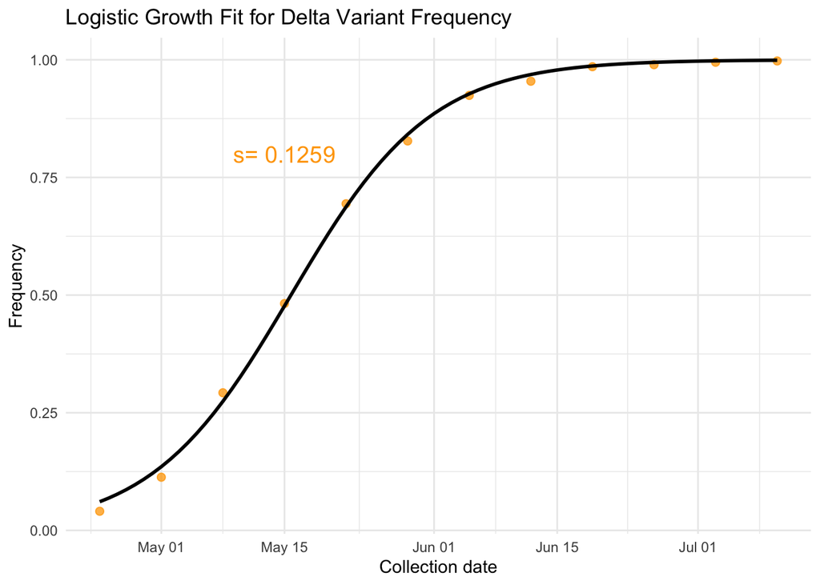

```r
#calculating the time-to-fixation for B.1.617.2

#we use the smoothened predictions, and find the date where the virus reaches a "fixation" level of 0.99 (99%)

fixed_B.1.617.2 <- smoothened_B.1.617.2_predictions %>%
  filter(predicted_frequency >= 0.99) %>%
  summarize(fixation_date = min(date))

#we then need to find the date of emergence (init_date), where frequency is >0.01 (1%), from the beginning of our modelled period

B.1.617.2_init_date <- smoothened_B.1.617.2_predictions %>%
  filter(predicted_frequency >= 0.01 & date >= as.Date("2021-04-23")) %>%
  summarize(init_date = min(date))

#the fixation (fix) time, is the difference between the fixed date and the init date

B.1.617.2_fix_time <- as.numeric(fixed_B.1.617.2$fixation_date[1] - B.1.617.2_init_date$init_date[1])

#print

B.1.617.2_fix_time
```

```
## [1] 59
```

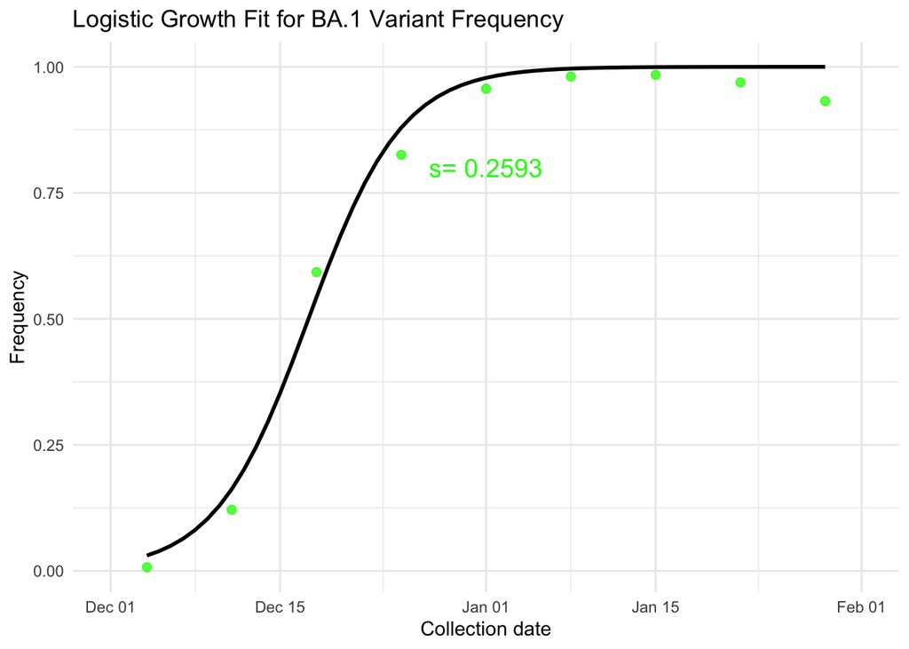

```
## [1] 32
```

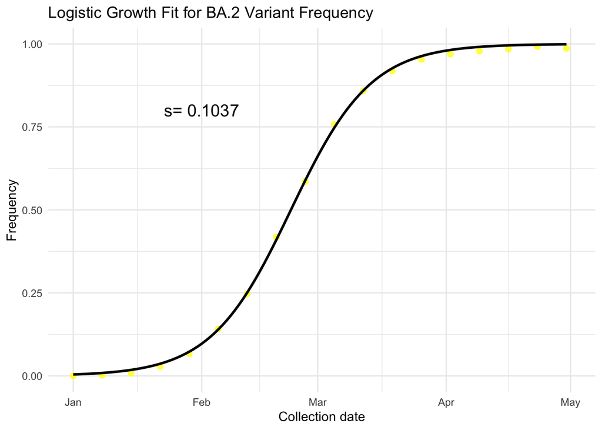

```
## [1] 88
```

*Which variant - B.1.617.2, BA.1 or BA.2 reached fixation the fastest?*

I chose to tackle this question by defining “reached fixation the fastest” as meaning “having the least time between its observed emergence, and the point at which its lineage frequency was >99%”, since it is methodologically almost impossible to measure fixation to the theoretical definition of 100%.

In order to calculate this, for each variant I found the date at which their respective lineage frequencies became > 99%, and subtracted this from the date of their observed emergence - thus giving rise to their “time-to-fixation”. This observed “time-to-fixation” is printed under each plot, as seen above, and summarised in the table below.

It is clear that:

Time-to-Fixation for different Strains

| Strain | Time-to-Fixation |
| --- | --- |
| B.1.617.2 | 59 |
| BA.1 | 32 |
| BA.2 | 88 |

As such, the speed of fixation was: **BA.1 > B.1.617.2 > BA.2**.

Ultimately, BA.1 reached fixation the fastest.

*Which variant - B.1.617.2, BA.1 or BA.2 exhibited the highest selective advantage under a logistic growth model?*

The “selective advantage” is calculated as the selection coefficient (*s*), is printed in a visible location in each graph.

The formula for the selection coefficient is the following:

$$\log \left( \frac{f(t)}{1 - f(t)} \right) = s \cdot t + f(0)$$

where:

- $f(t)$ is the lineage frequency at time $t$,
- $s$ is the selection coefficient (sometimes generalised as the growth rate), and
- $f(0)$ is the initial, non-zero variant frequency.

It is clear that:

Selective advantage (s) of different strains

| Strain | Selective Advantage | Growth Speed (%) |
| --- | --- | --- |
| B.1.617.2 | 0.1259 | 12.6% |
| BA.1 | 0.2593 | 25.9% |
| BA.2 | 0.1037 | 10.4% |

As such, the s between variants is: **BA.1 > B.1.617.2 > BA.2**.

Ultimately, BA.1 had the highest selective advantage under this logistic growth model.

It is pleasing that the time-to-fixation and selective advantage patterns recapitulate one another, as it corroborates the observation that BA.1 had the fastest time to fixation, demonstrating a stronger selective advantage, than B.1.617.2, and (s)lowest being BA.2. If the patterns did not match, it would be a clue that there had been a methodological error, as we expect these traits to correlate mathematically, and biologically.

### Question 4:

#### 1) **Load the dataset:** download and load delta-d2.rds.

```r
#load the delta dataset into R

delta_raw <- readRDS("/Users/Shared/SARS/data/delta_raw.rds")

#cleaning the regional NAs from the data

delta_clean <- subset(delta_raw, phecname != "")
```

#### 2) Analyse and Visualise the Data.

2i) Plot Delta frequencies by region over time. Use distinct colours or facets to differentiate between regions.

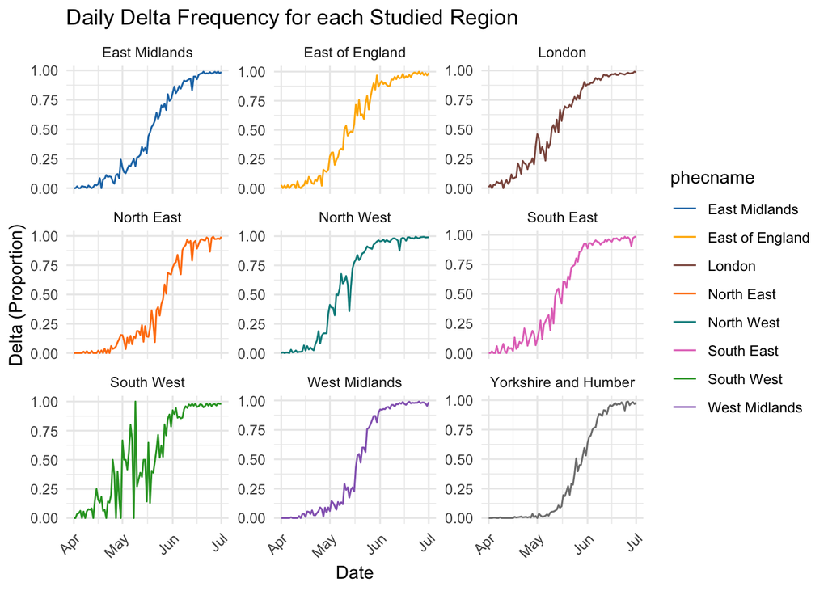

```r
#creating a custom palette for each region

custom_palette <- c(
  "East Midlands" = "#1f77b4", # Blue
  "North East" = "#ff7f0e", # Orange
  "South West" = "#2ca02c",  # Green
  "East of England" = "#FFB400",  # again, I am replacing the red with amber, to be more colour-blind friendly
  "North West" = "#008B8B",  # Teal
  "West Midlands" = "#9467bd",  # Purple
  "London" = "#8c564b",  # Brown
  "South East" = "#e377c2",  # Pink
  "York and Humber" = "#D2B48C"  # Light brown
)

#visualising a multi-facet plot for the regional frequency data

ggplot(delta_daily_frequency, aes(x = date, y = true_frequency, color = phecname)) +
  geom_line() +
  facet_wrap(~ phecname, scales = "free_y") +  # this creates separate facets for each region
  scale_color_manual(values = custom_palette) +
  labs(title = "Daily Delta Frequency for each Studied Region",
       x = "Date",
       y = "Delta (Proportion)") +
  theme_minimal() +
  theme(axis.text.x = element_text(angle = 45, hjust = 1))
```

2ii) Fit a logistic growth for each region. Overlay the logistic growth curves onto the frequency trajectories for each region.

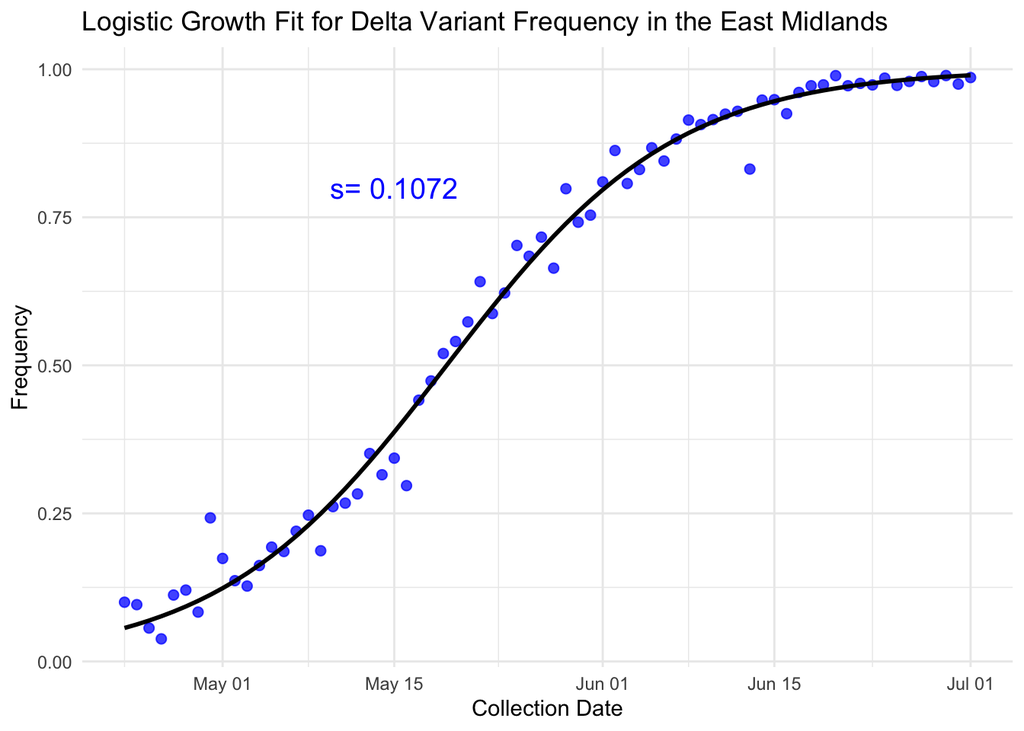

```
## [1] 27
```

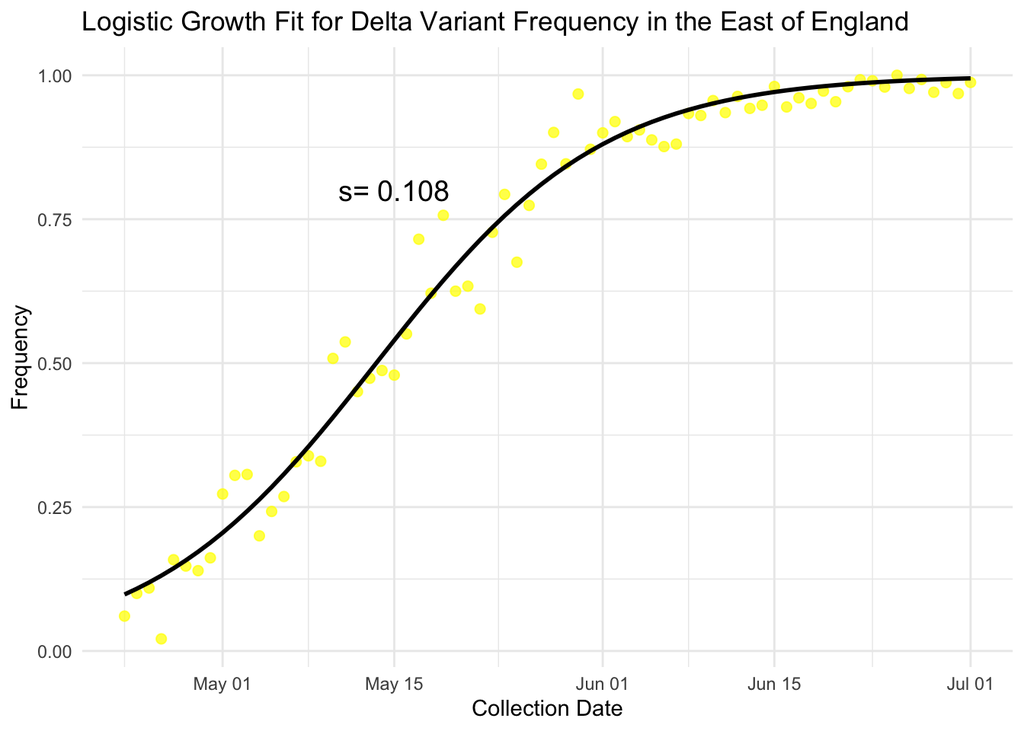

```
## [1] 21
```

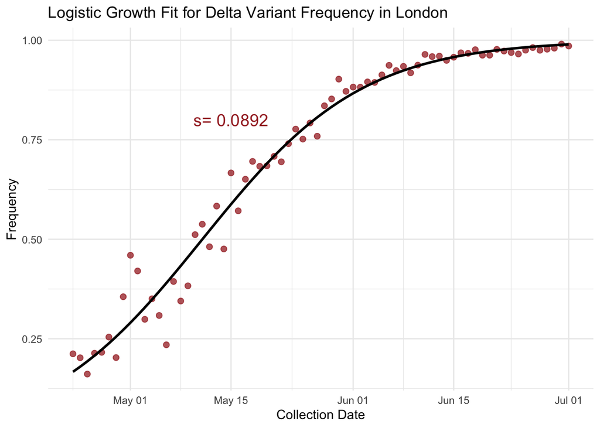

```
## [1] 19
```

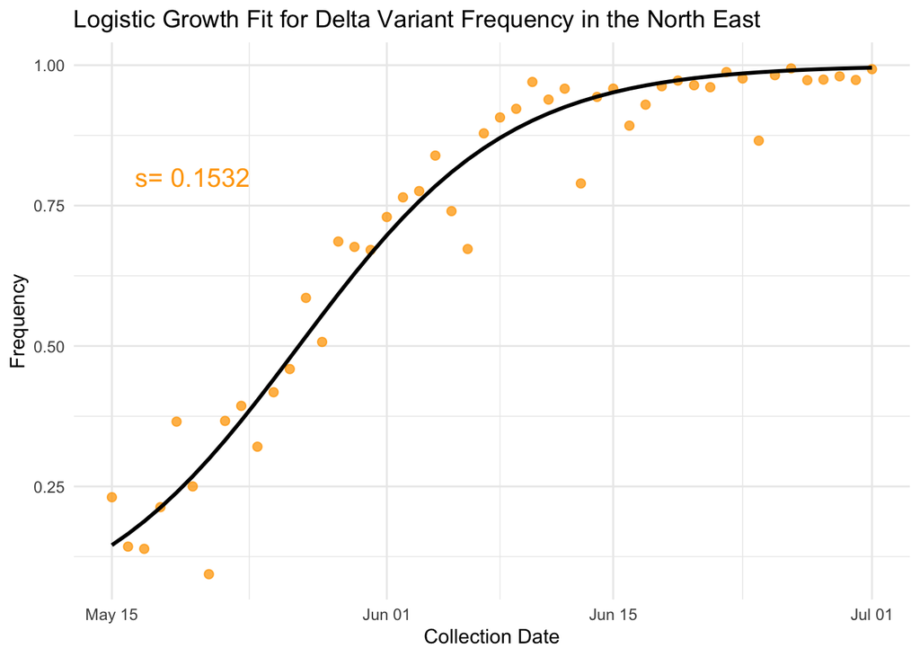

```
## [1] 12
```

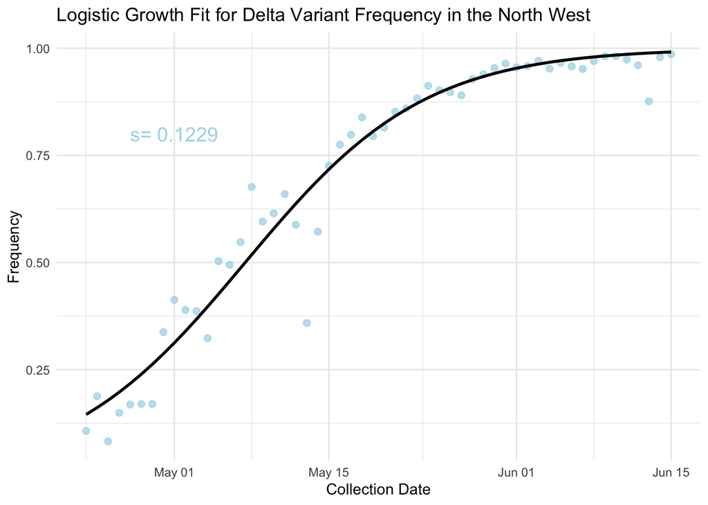

```
## [1] 15
```

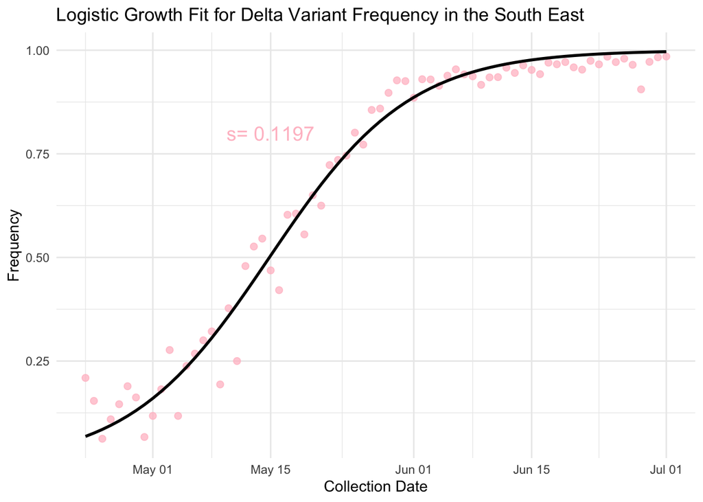

```
## [1] 22
```

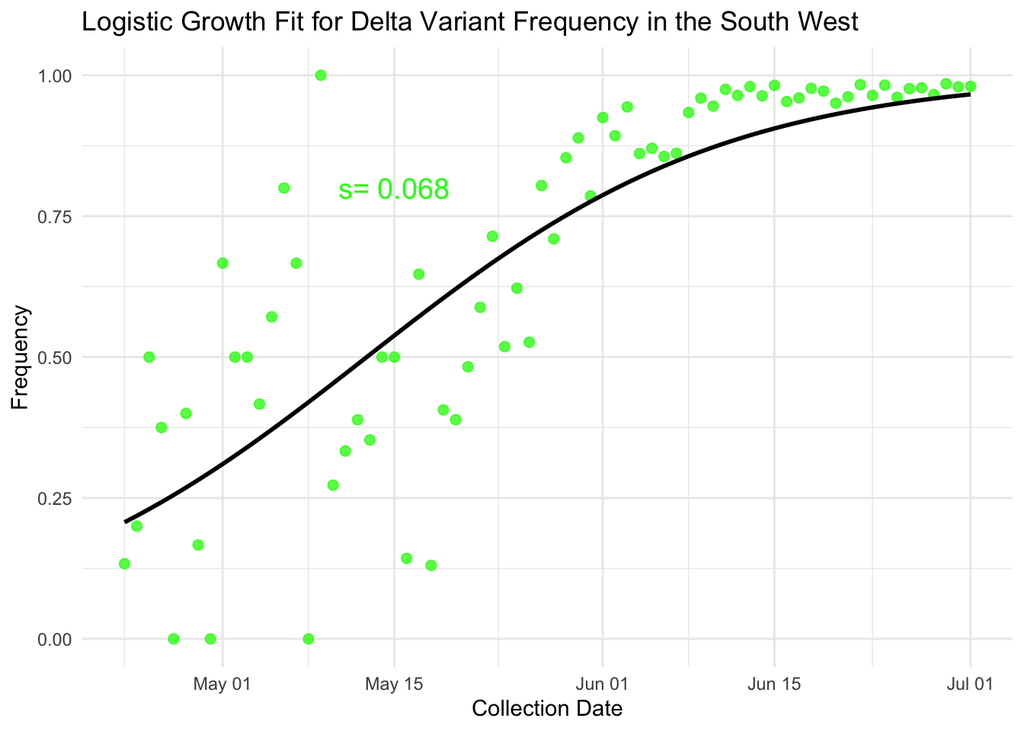

```
## [1] 20
```

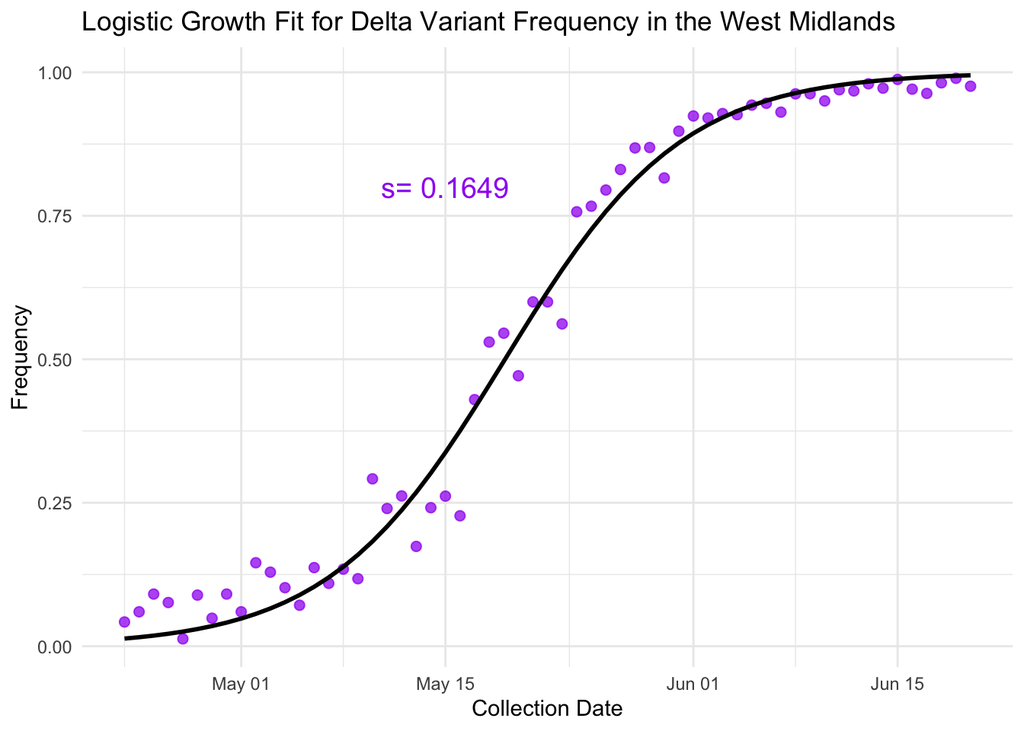

```
## [1] 27
```

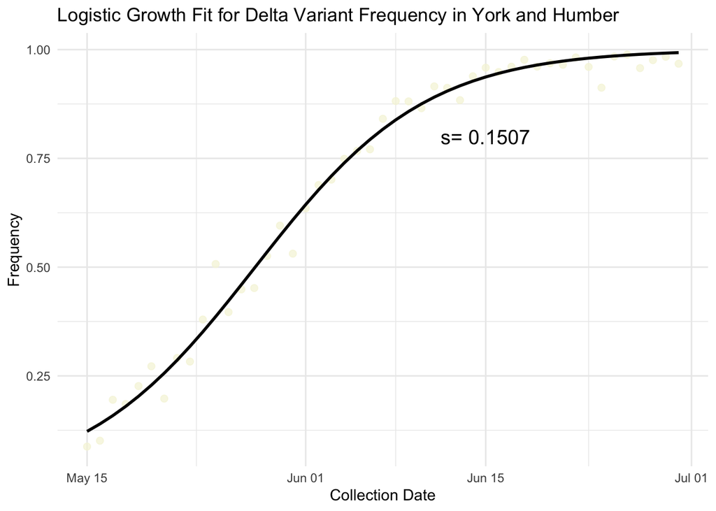

```
## [1] 14
```

#### 3) Interpretation:

**3i)**

**Identify the region with the fastest Delta outbreak:**

In order to determine the region with the “fastest Delta outbreak”, we can use a modified idea of the “selective advantage” (s). In this case, the selective advantage would simply refer to the growth rate of the strain within that particular region.

Here, it is clear that:

| Region | s | Speed of Outbreak (%) |
| --- | --- | --- |
| East Midlands | 0.1072 | 10.7 |
| North East | 0.1532 | 15.3 |
| South West | 0.068 | 6.8 |
| East of England | 0.108 | 10.8 |
| North West | 0.1229 | 12.3 |
| London | 0.0892 | 8.9 |
| South East | 0.1197 | 12 |
| York and Humber | 0.1507 | 15.1 |
| West Midlands | 0.1649 | 16.5 |

As such, according to their selective advantages, the fastest Delta outbreaks occured in the following order:

The West Midlands > The North East > York and Humber > The North West > The South East > The East of England > The East Midlands > London > The South West.

Ultimately, the region with the fastest Delta outbreak was the West Midlands.

**Identify the region where Delta had the earliest rise in frequencies:**

According to (Volz 2021), a “rise in frequency” can be defined as reaching 50% of a region. This can therefore be defined as the “time-to-rise”.

Here, it is clear that:

Time-to-Rise of Delta across Regions

| Region | Time-to-Rise |
| --- | --- |
| East Midlands | 27 |
| North East | 12 |
| South West | 20 |
| East of England | 21 |
| North West | 15 |
| London | 19 |
| South East | 22 |
| York and Humber | 14 |
| West Midlands | 27 |

As such, the time-to-rise (defined by speed) across regions was the following:

The North East > York and Humber > The North West > London > The South West > The East of England > The South East > The East Midlands = The West Midlands.

**Discuss why the timing of Delta’s emergence differed between regions:**

The differing timing of Delta’s emergence between regions can be chiefly explained through network theory. Certain urban regions (like London, for example) are likely to house individuals that travel more - from a network perspective, they exhibit high connectivity. This is likely to allow Delta to emerge earlier, from its origin in India. From there, the secondary regions with the highest connectivity to the focal area are likely to experience secondary emergence (McCrone 2022). The trickles down until the regions with the lowest connectivity to the focal region experience Delta emergence last.

**3ii) Could Delta’s growth across regions be associated with a founder effect?**

*What is the founder effect?*

The founder effect can be described as the loss of genetic variation that occurs during the colonisation of a new environment by a small group of individuals (Matute 2013).

*Does our observed data support or refute the hypothesis that Delta’s growth across regions is associated with a founder effect?*

Data that supported Delta’s growth across regions as being associated with a founder effect would show a rapid emergence, followed by sequential disparate emergence events in different regions, that rapidly rose to prominence in the regions, in the form of a fast outbreak. This is because the novel introduction of new genetic viral content would facilitate spread of the pocket of founding individuals. Our data do show a rapid rise to prominence and fast outbreaks across regions (although we have not compared this to any other strains as a baseline). As such, there is initial evidence of a founder effect in Delta. However, this would need to be complemented by genetic data, which could investigate whether the initial focal points of Delta emergence exhibited viruses with a higher genetic variation, and whether the secondary emergence events at the connected foci were associated with a lower genetic variation. This could be further corroborating evidence of a founder effect associated with Delta in the UK.

### Question 5:

#### 1) **Estimate the true incidence of Delta**

*Does the number of PCR-positive tests sent to the Sanger Institute for sequencing reflect the true incidence of Delta infections in England?*

No, because many people are likely to be infected, but not take a PCR test. This includes individuals who are, for example:

1. asymptomatic
2. elderly, disabled or infirm, and cannot access the PCR test
3. geographically isolated, and therefore do not have access
4. socioeconomically deprived, and therefore do not have access, or would not want to experience the consequences of a positive test (i.e. time off work or social isolation)

This not only varies from individual-to-individual, but also regionally; due to the dependence of testing upon infrastructure and policy.

At the next stage downstream, not all of the PCR tests that are actually returned as positive are sent to the Sanger institute for sequencing, based on being representative of UK households.

Finally, in the temporal dimensions, there will be an associated time delay between an individual testing positive for PCR, and the associated sequencing event at the Sanger Institute. This means that incidence reporting is likely to be necessarily delayed under this approach.

*How does the sequencing approach differ from incidence?*

Incidence can be defined as the daily number of new infections (Ma 2023). Studying incidence has the aim of appreciating an epi/pandemic spread, and therefore aims to take into account all positive individuals.

However, this sequencing approach does not necessarily show the daily number of new infections. This is because it has a different purpose altogether - it takes a systematic representative *sample* from UK households in order to understand the count data of various lineages, under an evolutionary lens. Whilst this lineage-based approach is interesting and worthwhile as it adds a evolutionary dimension to the purely numerical incidence understanding of disease transmission, the complexity of the approach means that the daily number of new infections is too far outside of a sequencing-approach scope, as it would essentially be looking to build an incidence consensus. Notably, it is probable impossible to measure the true daily number of new infections, due to the reasons listed above. As such, all response variables utilised in epidemiology are essentially our best effort to achieve proxies for incidence.

To obtain a more representative estimate of the true number of Delta infections, multiply the proportion of Delta sequences in England (from the Sanger dataset) by the daily (7-day averaged) COVID-19 case counts in England provided in the daily-new-confirmed-covid-19-cases.csv dataset.

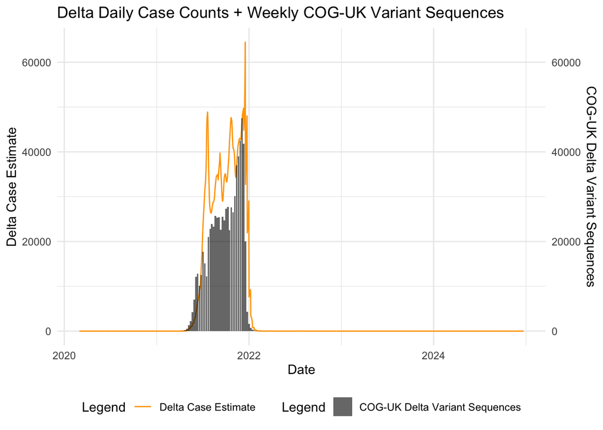

*Why are these two counts different from each other?*

The daily data counts are attempting to proxy incidence. They are a measure of the number of positive PCR tests each day, which we have filtered for Delta. However, the weekly sequencing approach is not trying to proxy incidence, but it conducting its own evolutionary analysis. This explains the lower frequency of measurements (as it is not trying to appreciate bulk growth of the epi/pandemic, but a more fine-tuned genetic approach).

As to why we observe the higher values in the daily case estimate (as perceived by the orange lines generally being above the black), this is because of the greater frequency of data collection (daily as opposed to weekly) being more likely to collect data that might be otherwised missed. This is compounded by the lag of a time lag, which is associated with sequence data, but not daily incidence (which simply relies on a PCR, and not the downstream, more time-consuming sequencing element). However, it is interesting that the sequence data appears to initially show a higher true incidence. We do not know if this is significant or not, as no statistical test has been run. However, it is an interesting clue into the sequencing approach, and about how its purpose to screen for lineages might result in the faster identification of newer emerging lineages, before the higher data collection rate of the daily case count can compensate for this.

#### 2) **Measure Rt**

Using the estimated daily Delta case counts, calculate the time-varying reproduction number (𝑅𝑡):

𝑅𝑡=𝐼(𝑡)∑𝑡𝑠=1𝐼(𝑡−𝑠)𝑤(𝑠)

where 𝐼(𝑡) is the incidence at time 𝑡 , and 𝑤(𝑠) is the probability mass function of the serial interval at lag 𝑠.

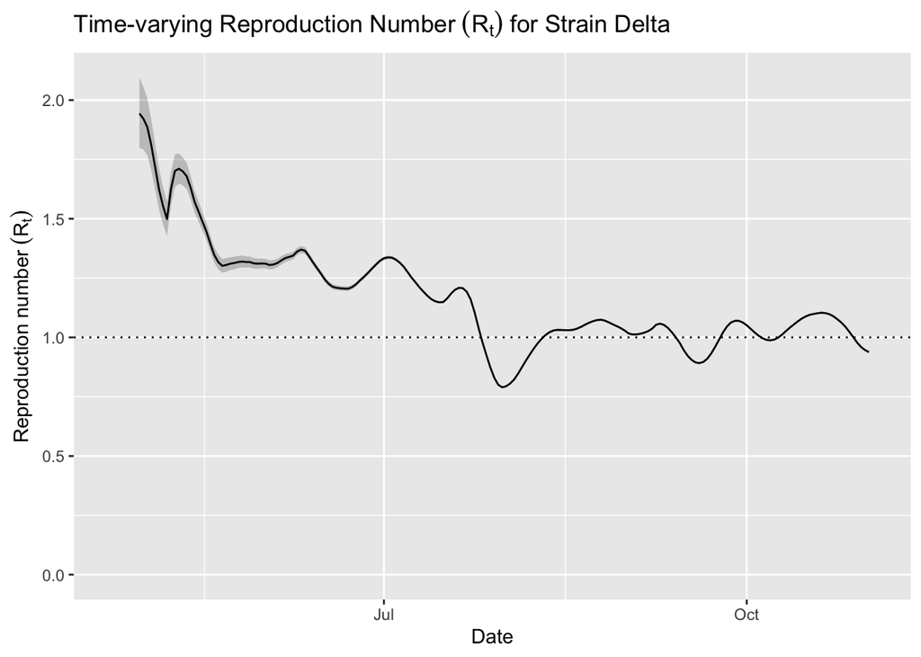

**Compare your 𝑅𝑡 estimate to the one calculated during the practical using the ONS-CIS dataset:**

In the practical, using the ON-CIS data, the R<sub>t</sub> was 1.85.

*Which estimate do you consider more reliable, and why?*

Personally, I would consider the ON-CIS dataset more likely to provide a reliable Rt. This is because, despite the extra noise introduced by the sequencing approach, it is systematic and representative in nature (as explored fully during Question 2). Notably, the ability of systematic (as opposed to opportunistic) data gathering approaches to provide a more reliable R<sub>t</sub> is supported by pre-existing literature (Sherratt 2021).

Ferguson, Jake, M. 2014. “Optimal Sampling Strategies for Detecting Zoonotic Disease Epidemics.” *National Library of Medicine* 10 (6): 1–13. https://doi.org/10.1371.

Fry, Hannah. 2020. “UK Population Density One Factor in Covid-19 Spread,” May. https://www.ucl.ac.uk/news/headlines/2020/may/uk-population-density-one-factor-covid-19-spread.

Ma, Yifei. 2023. “Model-Based Analysis of the Incidence Trends and Transmission Dynamics of COVID-19 Associated with the Omicron Variant in Representative Cities in China.” *BMC Public Health* 2 (23): 2400. https://doi.org/https://doi.org/10.1186/s12889-023-17327-7.

Matute, D., R. 2013. “The Role of Founder Effects on the Evolution of Reproductive Isolation.” *OXFORD ACADEMIC* 26 (11): 22992311. https://doi.org/10.1111.

McCrone, John, T. 2022. “Context-Specific Emergence and Growth of the SARS-CoV-2 Delta Variant.” *Nature* 610 (1): pages 154160. https://doi.org/10.1038.

Parnell, S. 2015. “Early Detection Surveillance for an Emerging Plant Pathogen: A Rule of Thumb to Predict Prevalence at First Discovery.” *Proceedings of the Royal Society of Biology B* 282 (1814): 1–9. https://doi.org/20151478.

Peacock, Sharon. 2021. “Q&a with Sharon Peacock, Coronavirus Variant Hunter,” February. https://www.cam.ac.uk/research/discussion/qa-with-sharon-peacock-coronavirus-variant-hunter.

Sherratt, Katharine. 2021. “Exploring Surveillance Data Biases When Estimating the Reproduction Number: With Insights into Subpopulation Transmission of COVID-19 in England.” *Royal Society of Biology Proceedings B* 376 (1): 1–10. https://royalsocietypublishing.org/doi/10.1098/rstb.2020.0283.

Volz, Erik. 2021. “Assessing Transmissibility of SARS-CoV-2 Lineage b.1.1.7 in England.” *Nature* 593 (1): 266269. https://doi.org/10.1038.